# Final Project Report

Carrie Cheng

2022-11-30

# Introduction

Higher accuracy in disease prediction would largely help patients and doctors. However, modern day data sets are usually complex, and the traditional statistical models for prediction might not be enough. Therefore, in this project, we aim to analyze whether machine learning algorithms would outperform the traditional logistic regression in a classification problem under the context of predicting disease. We will look at the chronic kidney disease data set from the UCI machine learning repository, and investigate which model out of the traditional statistical model and machine learning models could best classify the development of chronic kidney disease.

The data set has 25 variables. One of these variables is the binary outcome variable recording whether the patient develops the kidney disease. The rest of the variables record the clinical information of the patients such as age, blood pressure, specific gravity, albumin, sugar, red blood cells, pus cell and bacteria. The data set contains both quantitative variables such as age, blood pressure, and sodium, and qualitative data such as albumin, sugar, hypertension. The data has missing values. To deal with the missing values, we impute the missing values with the mean of each variable excluding the missing values for quantitative variables, and the lowest or reference category for categorical variables. For example, for the variable hypertension, the missing values are replaced by no hypertension (htn = 0).

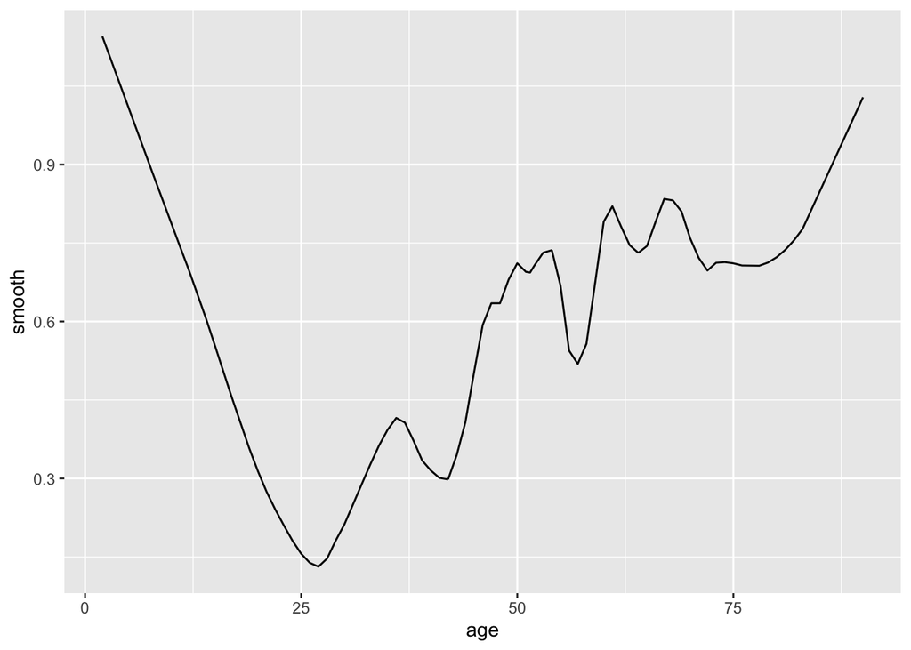

After coding all the variables with qualitative descriptions into categorical variables with different levels or factors and filling the missing values as described above, we are ready to conduct an exploratory data analysis. From the plot, we see that age and the outcome might have a nonlinear relationship. Therefore, we calculate the pearson correlation to see the strength of linear relationship between each variable and the outcome.

```
##       pearson correlation with outcome     p values
## age                         0.21787598 1.098513e-05
## bp                          0.29136656 2.877686e-09
## sg                         -0.65970612 0.000000e+00
## al                          0.52337662 0.000000e+00
## su                          0.26625071 6.436108e-08
## rbc                         0.28870505 4.059777e-09
## pc                          0.35700856 1.814104e-13
## pcc                         0.23748477 1.557398e-06
## ba                          0.19087904 1.225307e-04
## bgr                         0.39005523 4.440892e-16
## bu                          0.37981834 3.552714e-15
## sc                          0.29697131 1.377874e-09
## sod                        -0.33828027 3.642864e-12
## pot                         0.07699492 1.242047e-01
## hemo                       -0.72217253 0.000000e+00
## pcv                        -0.68935489 0.000000e+00
## wbcc                        0.21059989 2.171006e-05
## rbcc                       -0.58231038 0.000000e+00
## htn                         0.57113322 0.000000e+00
## dm                          0.52126341 0.000000e+00
## cad                         0.24115247 1.059976e-06
## appet                      -0.35747752 1.678657e-13
## pe                          0.37010498 1.976197e-14
## ane                         0.31798693 7.537082e-11
## class                       1.00000000           NA
```

From the table, we see that the absolute values of the pearson correlation mostly do not exceed 0.5, which means that most of the variables appear to have a weak linear correlation with the outcome. However, we see that their corresponding p values are small, which indicates that the variables are associated with the outcome. Therefore, we need to consider flexible models which could capture complex and nonlinear relationship between predictors and the outcome. Under the classification context, classification tree and random forests allow for flexible splits in each variable, which could help learning complicated information from the data. Specifically, random forests might perform more stable than a single classification tree because it bootstraps the data sample and take an average over differently trained trees. K-nearest neighbors and naive bayes could also provide insights in performance of flexible modelings under different approaches.

# Results

In order to investigate whether machine learning algorithms could capture more complex relationships between predictors and outcome, we will apply flexible models including classification trees, random forests, k-nearest neighbors, and naive bayes. First, we will train each algorithm with fixed parameters using only one train and test set for a reference purpose. We will also train a logistic regression in order to establish a comparison on the performance between the traditional statistical methods and the machine learning algorithms. For random forests, we set the number of trees trained to be 100, and for k-nearest neighbors, we set the number of neighborhood to be 5.

In general, random forests perform the best in terms of an aggregate of the metrics, and logistics regression has an average performance. However, we see that k-nearest neighbors performs the worst of the five algorithms in terms of each metric. This might due to the fact that the k-nearest neighbors simply take an average over its neighbors and might ignore some complex relationship between predictors and outcome and their variability while performing the predictions.

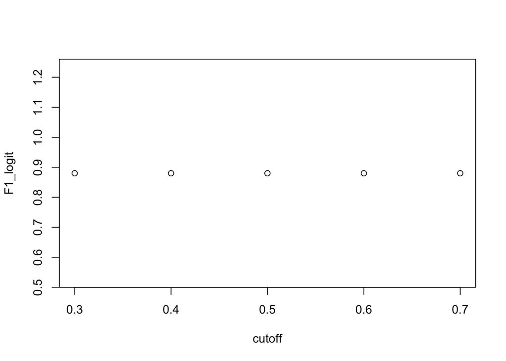

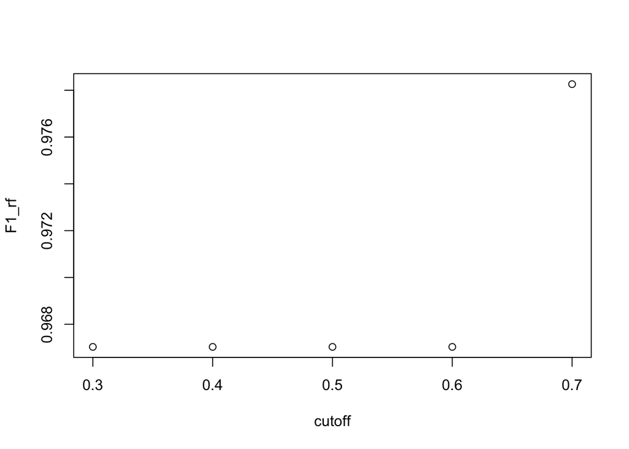

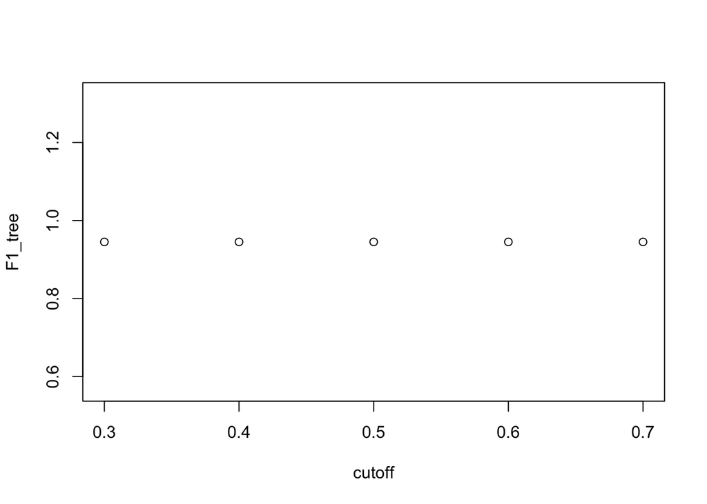

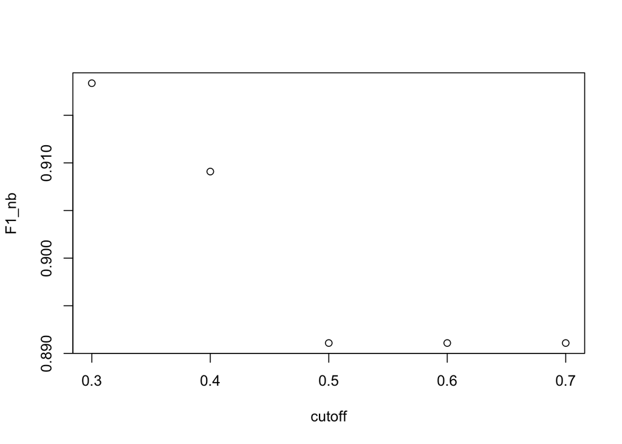

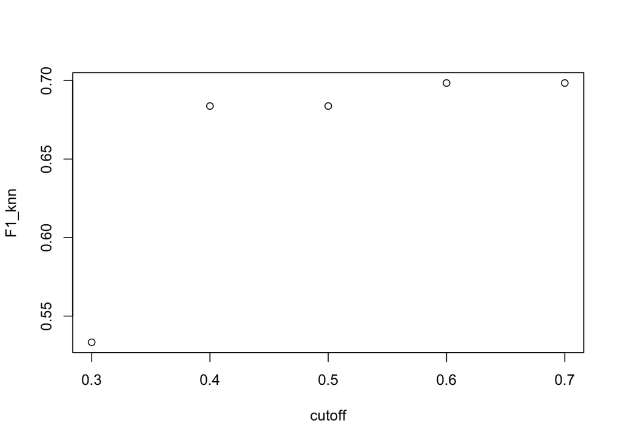

Nevertheless, these results are only based on a single cross-validation set with fixed parameters. However, the performance of these algorithms might differ with different parameters. Therefore, we will implement a common practice of parameter tuning using a 10-fold cross-validation and record the best tuned model. We will analyze whether parameter tuning improves the performance for each algorithm. Specifically, we will compare the tuning parameters with the accuracy. Since there is no tuning parameter for logistic regression, we will only train the model with a 10-fold cross-validation.

We will start with random forests. There are several parameters that could be tuned for random forests such as the number of variables randomly selected, the size of each node, and number of trees trained. Here, we will investigate the accuracy versus the number of trees trained. We will train a random forests model for 10 different numbers of trees with a 10-fold cross-validation and we keep the number of variables randomly selected for placing splits as three.

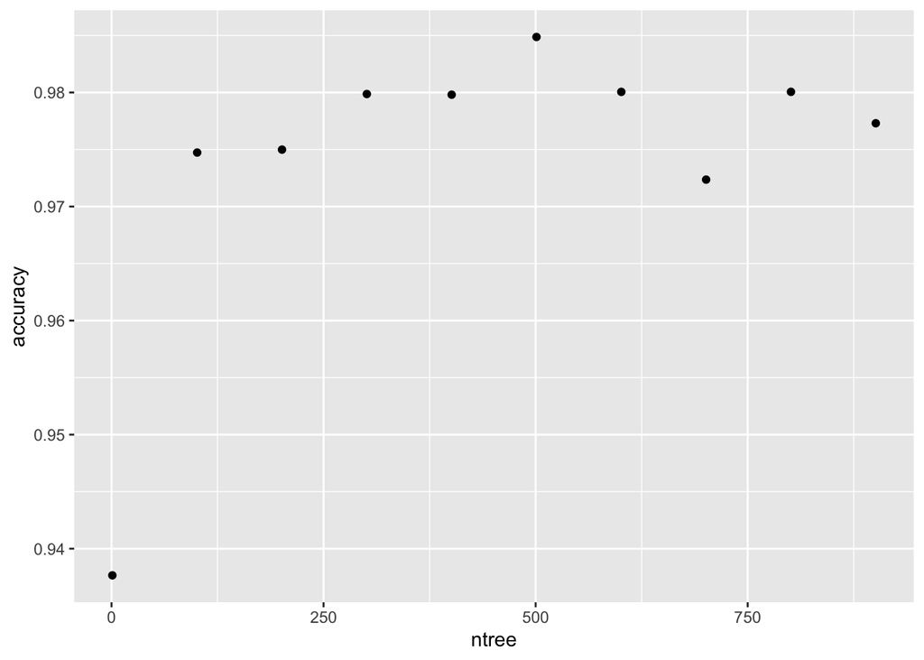

From the graph, we see that the accuracy is greatly boosted from training only one tree to 101 trees, and the accuracy stays approximately the same for even larger number of trees trained. This is a result from the bootstrapping and ensemble strategy for random forests. Since training one tree might produce great variability, bootstrapping the sample data, training trees repetitively, and taking averages across the individual trees might help the performance and reduce the variability of the outcome prediction. Therefore, having a large number of trees trained helps the accuracy of prediction.

Next, we will also look at the influence of number of variables randomly selected as predictors on the accuracy of prediction. In this tuning process, we trained random forests for 8 different number of variables randomly selected as predictors with a 10-fold cross-validation and plot them against the accuracy.

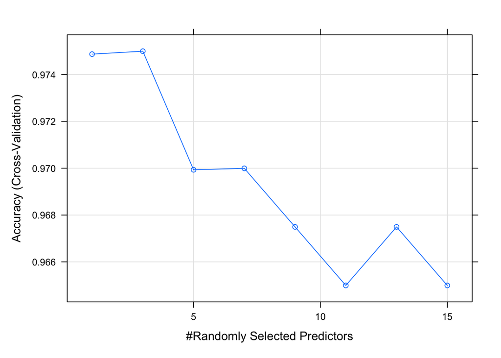

From the plot, we see that having three randomly selected predictors has the highest accuracy. However, the accuracy across different number of randomly selected predictors do not vary much and are generally close to each other. With contrast to number of trees trained, the accuracy of prediction is more sensitive to a small change in the number of randomly selected predictors. This is reasonable because different information will be learned by each individual tree when different variables are randomly selected as predictors, which would result in a variation of prediction accuracy.

Next, we will tune the classification tree using the complexity parameter ranging from 0 to 0.1 with a 10-fold cross-validation and plot them against the accuracy.

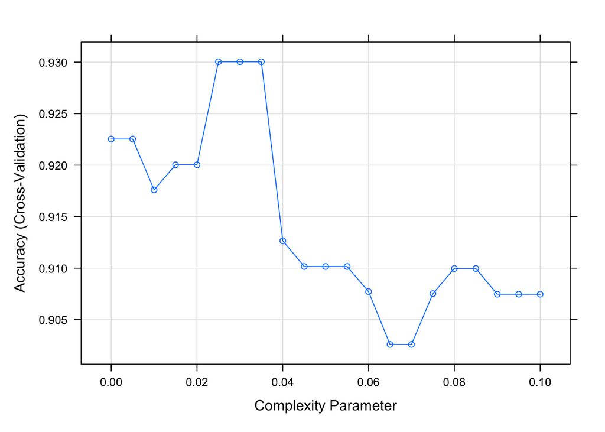

We will tune the number of neighbors for k-nearest neighbors with a 10-fold cross-validation and plot them against the accuracy.

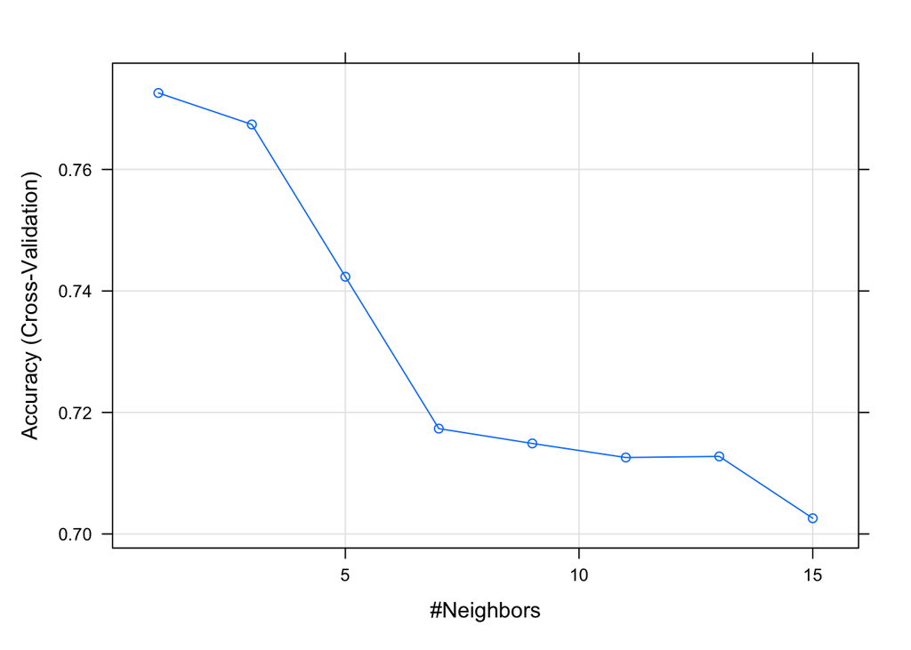

From the graph, we see that the highest accuracy occurs for one number of neighbor. This might be due to that the predictors in the data set have a wide and varying range. We also see that the overall accuracy of k-nearest neighbor is low even though the accuracy is higher when number of neighbor is one.

We will tune the bandwidth or flexibility of the kernel density and the laplace smoothing correction for naive bayes using a 10-fold cross-validation and plot them against the accuracy.

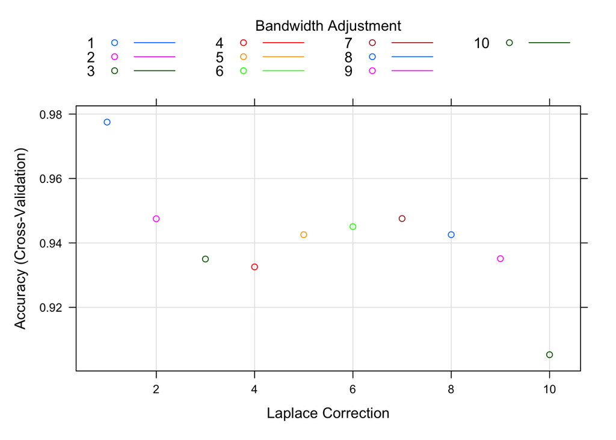

From the graph, we see that the accuracy is highest when bandwidth adjustment and laplace correction both equal to 1.

Finally, we train a logistic regression with a 10-fold cross-validation since there is no tuning parameter for logistic regression.

Now, let’s compare the best tuned models.

|  | Accuracy |
| --- | --- |
| random forest | 0.9749969 |
| tree | 0.9300360 |
| knn | 0.7725907 |
| naive bayes | 0.9774969 |
| logit | 0.9301032 |